# R Day

In RMarkdown files (*.Rmd), you can add headers using the pound symbol (#). For example:

# This is my header.

## And a smaller header.

Underneath headers, I can describe other things that I am doing…. In R script files (.R), however, # serves to comment out R code that you do not want to execute. Similarly, if you embed your R code in your RMarkdown file, the # will work in the same way as it would in an R script file. For example, I can insert a block of R code and show this here:

```r
# I use the pound symbol in R code to indicate that I don't want this line of code to run
# 4 + 4

# If I don't use the pound symbol, RMarkdown will run/execute the code.
8 + 8
```

```
## [1] 16
```

If I need a certain library to execute code, I can load them.

```r
library("psych")
library("moments")
```

I can check to see what my working directory is to make sure it’s correct.

```r
getwd() # This should be Psyc109 on your desktop
```

```
## [1] "G:/Dropbox/Progs/_install/R/Exercises"
```

Because my data file is in my working directory, I can read in the csv file and assign the file to an R data frame objec with a certain name. I can read the data from the Center for Disease Control and assign that data frame to an object named cdc and make sure that it’s a data frame.

```r
cdc <- read.csv("cdc.csv")
is.data.frame(cdc) # Determine if the data is a data frame object. Should return TRUE
```

```
## [1] TRUE
```

I can look a the structure of the data frame so that I can see how many vector/variables there are and what type they are. And I can also take a look at what the data frame looks like by looking at the first or last several cases.

```r
str(cdc) # Let's you know the type of the data (e.g., numeric, integer, Factor, etc.)
```

```
## 'data.frame':    20000 obs. of  9 variables:
##  $ genhlth : Factor w/ 5 levels "excellent","fair",..: 3 3 3 3 5 5 5 5 3 3 ...
##  $ exerany : int  0 0 1 1 0 1 1 0 0 1 ...
##  $ hlthplan: int  1 1 1 1 1 1 1 1 1 1 ...
##  $ smoke100: int  0 1 1 0 0 0 0 0 1 0 ...
##  $ height  : int  70 64 60 66 61 64 71 67 65 70 ...
##  $ weight  : int  175 125 105 132 150 114 194 170 150 180 ...
##  $ wtdesire: int  175 115 105 124 130 114 185 160 130 170 ...
##  $ age     : int  77 33 49 42 55 55 31 45 27 44 ...
##  $ gender  : Factor w/ 2 levels "f","m": 2 1 1 1 1 1 2 2 1 2 ...
```

```r
head(cdc) # Shows the first few cases of your data set
```

```
##     genhlth exerany hlthplan smoke100 height weight wtdesire age gender
## 1      good       0        1        0     70    175      175  77      m
## 2      good       0        1        1     64    125      115  33      f
## 3      good       1        1        1     60    105      105  49      f
## 4      good       1        1        0     66    132      124  42      f
## 5 very good       0        1        0     61    150      130  55      f
## 6 very good       1        1        0     64    114      114  55      f
```

```r
tail(cdc) # Shows the last few cases of your data set
```

```
##         genhlth exerany hlthplan smoke100 height weight wtdesire age
## 19995      good       0        1        1     69    224      224  73
## 19996      good       1        1        0     66    215      140  23
## 19997 excellent       0        1        0     73    200      185  35
## 19998      poor       0        1        0     65    216      150  57
## 19999      good       1        1        0     67    165      165  81
## 20000      good       1        1        1     69    170      165  83
##       gender
## 19995      m
## 19996      f
## 19997      m
## 19998      f
## 19999      f
## 20000      m
```

```r
dim(cdc) # Shows the dimensions of the data frame; 20,000 observations; 9 columns
```

```
## [1] 20000     9
```

```r
names(cdc) # What are the column/variable names in the data frame?
```

```
## [1] "genhlth"  "exerany"  "hlthplan" "smoke100" "height"   "weight"
## [7] "wtdesire" "age"      "gender"
```

I can also View the data frame in a more user-friendly viewer as well as examing the descriptive statistics of certain variables by specifying the data frame object (e.g., cdc) and the vector/variable I wish to examine.

```r
View(cdc) # View the data file
mean(cdc$weight) #Shows the Mean of the variable weight
```

```
## [1] 169.683
```

```r
median(cdc$weight) #Shows the Median of the variable weight
```

```
## [1] 165
```

```r
var(cdc$weight) #Shows the variance of the variable weight
```

```
## [1] 1606.484
```

```r
sd(cdc$weight) #Shows the Standard Deviation of the variable weight
```

```
## [1] 40.08097
```

```r
summary(cdc$weight) #Provides a summary of the variable weight
```

```
##    Min. 1st Qu.  Median    Mean 3rd Qu.    Max.
##    68.0   140.0   165.0   169.7   190.0   500.0
```

```r
skewness(cdc$weight) #Shows the Skewness of the variable weight
```

```
## [1] 0.9556563
```

```r
kurtosis(cdc$weight) #Shows the Kurtosis of the variable weight
```

```
## [1] 4.995356
```

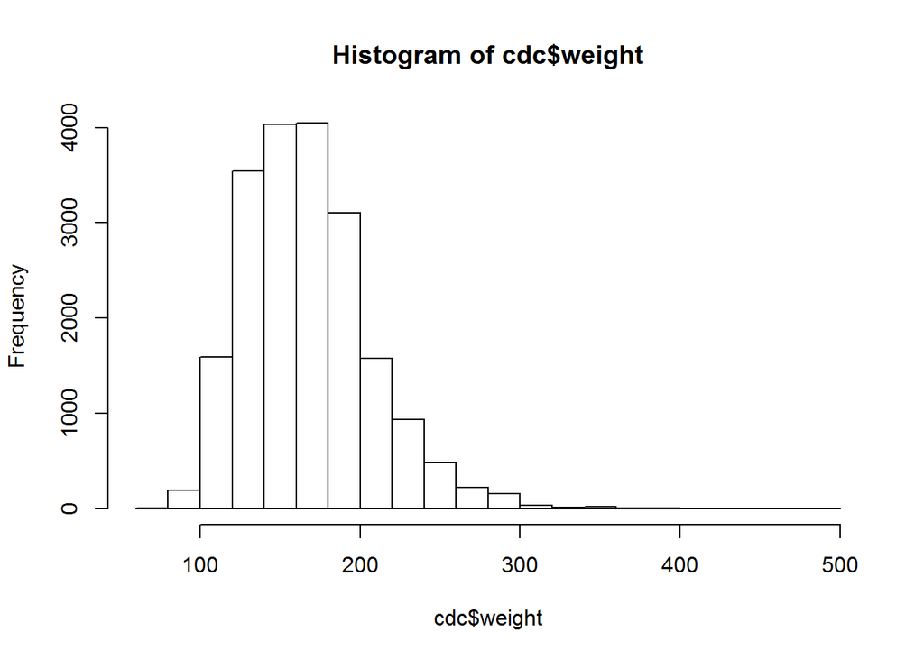

```r
hist(cdc$weight) #Produces a simple histogram of the variable weight
```

Once I am done with my coding, I can save my RMarkdown file (*.Rmd) and click the Knit HTML button to produce a pretty HTML file. This file will also be saved in my working directory (Psyc109) and will have the same name as my* .Rmd file.